# 9.5: Batting average

## Introduction

This is the “Batting average” example in Section 9.5 of Kruschke (but with some changes).

## Preliminaries

Load necessary packages:

```r
library(tidyverse)
library(rstan)
library(shinystan)
library(bayesplot)
library(GGally)
```

Set Stan to save compiled code.

```r
rstan_options(auto_write = TRUE)
```

Set Stan to use parallel processing where possible.

```r
options(mc.cores = parallel::detectCores())
```

## Data

First we import the data. (Make sure the file “BattingAverage.csv” is in your project directory.)

```r
ba_data <- read_csv("BattingAverage.csv")
ba_data
```

| Player | PriPos | Hits | AtBats | PlayerNumber | PriPosNumber |
| --- | --- | --- | --- | --- | --- |
| Fernando Abad | Pitcher | 1 | 7 | 1 | 1 |
| Bobby Abreu | Left Field | 53 | 219 | 2 | 7 |
| Tony Abreu | 2nd Base | 18 | 70 | 3 | 4 |
| Dustin Ackley | 2nd Base | 137 | 607 | 4 | 4 |
| Matt Adams | 1st Base | 21 | 86 | 5 | 3 |
| Nathan Adcock | Pitcher | 0 | 1 | 6 | 1 |
| Jeremy Affeldt | Pitcher | 0 | 1 | 7 | 1 |
| Brandon Allen | 1st Base | 2 | 20 | 8 | 3 |
| Yonder Alonso | 1st Base | 150 | 549 | 9 | 3 |
| Jose Altuve | 2nd Base | 167 | 576 | 10 | 4 |

[output cut: 938 more lines]

The only change we need to the data we pass to Stan is that we have to tell it the number of categories `C`. There are 9 possible positions. We’ll pass the position number (`PriPosNumber`) to Stan as well.

```r
C <- 9
S <- NROW(ba_data) # number of subjects
N <- ba_data$AtBats # number of trials for each subject
y <- ba_data$Hits # number of successes for each subject
cats <- ba_data$PriPosNumber
stan_data <- list(C = C, S = S, N = N, y = y, cats = cats)
```

## Stan code

We incorporate player position to allow different values of $\omega$ and $\kappa$ for each position. There will still be a parameter called $\omega_{0}$ that will serve as the mode of the beta “hyper-hyperprior” whereas $\omega_{c}$ ($1 \leq c \leq 9$) will be the mode of the hyperprior for each category of player (informing the $\theta$ for each player). The same will be true for $\kappa_{0}$ versus the collection of $\kappa_{c}$.

The gamma hyperpriors on $\kappa$ turn out to cause divergent transitions. We’ll use an exponential distribution (with rate parameter 1) instead, from which Stan seems to be able to sample more easily.

We use vectors instead of arrays. This allows us to multiply things out without using `for` loops. For example, the lines

```
a = omega .* (kappa - 2) + 1;
b = (1 - omega) .* (kappa - 2) + 1;
```

use the operator `.*` instead of just `*`. That’s because `a` and `b` are actually vectors of length 9, as are `omega` and `kappa`. So each equation actually represents 9 different equations:

```
a[1] = omega[1] * (kappa[1] - 2) + 1;
a[2] = omega[2] * (kappa[2] - 2) + 1;
a[3] = omega[3] * (kappa[3] - 2) + 1;
...
```

In the `model` block, the sampling statement for `theta` also looks a little weird:

```
theta ~ beta(a[cats], b[cats]);
```

This is sampling 948 values, but `a[cats]` and `b[cats]` refer to only the nine possible values of `a` or `b` depedning on the category (position) of the player for whom we’re sampling `theta`.

```stan
data {
  int<lower = 0> C;
  int<lower = 0> S;
  int<lower = 0> N[S];
  int<lower = 0> y[S];
  int<lower = 0> cats[S];
}
transformed data {
  real<lower = 0> A_omega_0;
  real<lower = 0> B_omega_0;
  real<lower = 0> R_kappa_0;

  A_omega_0 = 2;
  B_omega_0 = 2;
  R_kappa_0 = 1;
}
parameters {
  vector<lower = 0, upper = 1>[S] theta;
  vector<lower = 0, upper = 1>[C] omega;
  vector<lower = 0>[C] kappa_minus_two;
  real<lower = 0> kappa_minus_two_0;
  real<lower = 0, upper = 1> omega_0;
}
transformed parameters {
  real<lower = 2> kappa_0;
  vector<lower = 2>[C] kappa;
  real<lower = 0> a_0;
  real<lower = 0> b_0;
  vector<lower = 0>[C] a;
  vector<lower = 0>[C] b;

  kappa_0 = kappa_minus_two_0 + 2;
  a_0 = omega_0 * (kappa_0 - 2) + 1;
  b_0 = (1 - omega_0) * (kappa_0 - 2) + 1;
  kappa = kappa_minus_two + 2;
  a = omega .* (kappa - 2) + 1;
  b = (1 - omega) .* (kappa - 2) + 1;
}
model {
  omega_0 ~ beta(A_omega_0, B_omega_0);
  kappa_minus_two_0 ~ exponential(R_kappa_0);
  omega ~ beta(a_0, b_0);
  kappa_minus_two ~ exponential(R_kappa_0);
  theta ~ beta(a[cats], b[cats]);
  y ~ binomial(N, theta);
}
generated quantities {
  int<lower = 0> y_rep[S];

  for (s in 1:S) {
    y_rep[s] = binomial_rng(N[s], theta[s]);
  }
}
```

## Sampling from the model

```r
set.seed(11111)
fit_ba <- sampling(ba, data = stan_data, refresh = 0)
```

## Diagnosing the model

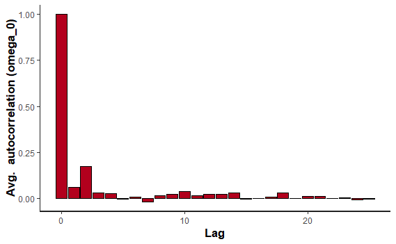

```r
plot(fit_ba, plotfun = "ac",
     pars = c("omega_0"))
```

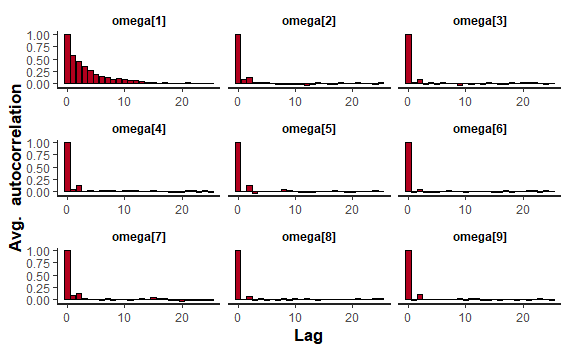

```r
plot(fit_ba, plotfun = "ac",
     pars = c("omega"))
```

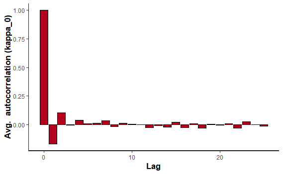

```r
plot(fit_ba, plotfun = "ac",
     pars = c("kappa_0"))
```

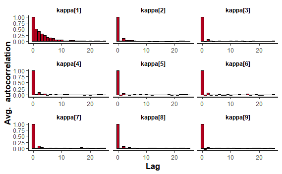

```r
plot(fit_ba, plotfun = "ac",
     pars = c("kappa"))
```

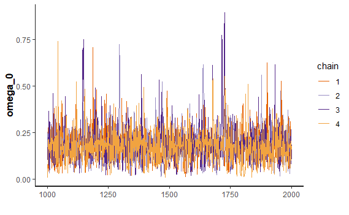

```r
plot(fit_ba, plotfun = "trace",
     pars = c("omega_0"))
```

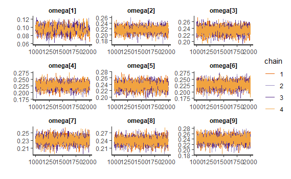

```r
plot(fit_ba, plotfun = "trace",
     pars = c("omega"))
```

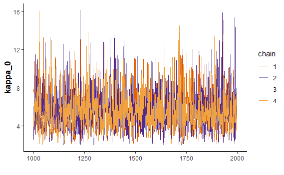

```r
plot(fit_ba, plotfun = "trace",
     pars = c("kappa_0"))
```

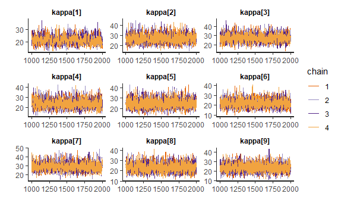

```r
plot(fit_ba, plotfun = "trace",
     pars = c("kappa"))
```

## Summarizing the model

```r
print(fit_ba, pars =  c("omega_0", "omega", "kappa_0", "kappa"))
```

```
Inference for Stan model: stan-3154217e7b7a.
4 chains, each with iter=2000; warmup=1000; thin=1;
post-warmup draws per chain=1000, total post-warmup draws=4000.

          mean se_mean   sd  2.5%   25%   50%   75% 97.5% n_eff
omega_0   0.18    0.00 0.09  0.04  0.12  0.17  0.23  0.38  2360
omega[1]  0.09    0.00 0.01  0.08  0.09  0.10  0.10  0.11   625
omega[2]  0.22    0.00 0.01  0.20  0.21  0.22  0.23  0.24  2516
omega[3]  0.23    0.00 0.01  0.21  0.23  0.23  0.24  0.26  3369
omega[4]  0.23    0.00 0.01  0.20  0.22  0.23  0.24  0.25  2537
omega[5]  0.23    0.00 0.01  0.21  0.23  0.24  0.24  0.26  3503
omega[6]  0.23    0.00 0.01  0.20  0.22  0.23  0.24  0.25  3949
omega[7]  0.23    0.00 0.01  0.21  0.22  0.23  0.24  0.25  2761
omega[8]  0.24    0.00 0.01  0.21  0.23  0.24  0.25  0.27  3509
omega[9]  0.24    0.00 0.01  0.21  0.23  0.24  0.25  0.27  3495
kappa_0   5.57    0.03 2.08  2.54  4.08  5.21  6.71 10.61  3817
kappa[1] 21.57    0.13 3.35 15.55 19.28 21.37 23.64 28.90   642
kappa[2] 26.71    0.08 4.31 19.08 23.65 26.41 29.49 35.68  2601
kappa[3] 27.13    0.08 4.47 19.01 24.09 26.88 29.94 36.56  3550
kappa[4] 23.78    0.08 4.33 16.02 20.75 23.50 26.45 32.97  2920
kappa[5] 25.09    0.07 4.28 17.65 22.10 24.81 27.78 34.30  4072
kappa[6] 21.99    0.07 4.25 14.43 18.94 21.65 24.64 31.11  3968
kappa[7] 29.40    0.08 4.62 21.25 26.22 29.08 32.25 39.54  3055
kappa[8] 23.13    0.08 4.34 15.40 20.12 22.80 25.78 32.52  3031
kappa[9] 23.39    0.07 4.42 15.62 20.31 23.04 26.23 32.52  4128
         Rhat
omega_0  1.00
omega[1] 1.01
omega[2] 1.00
omega[3] 1.00
omega[4] 1.00
omega[5] 1.00
omega[6] 1.00
omega[7] 1.00
omega[8] 1.00
omega[9] 1.00
kappa_0  1.00
kappa[1] 1.01
kappa[2] 1.00
kappa[3] 1.00
kappa[4] 1.00
kappa[5] 1.00
kappa[6] 1.00
kappa[7] 1.00
kappa[8] 1.00
kappa[9] 1.00

Samples were drawn using NUTS(diag_e) at Tue May 28 15:59:18 2019.
For each parameter, n_eff is a crude measure of effective sample size,
and Rhat is the potential scale reduction factor on split chains (at
convergence, Rhat=1).
```

Just a few of the $\theta$ parameters:

```r
print(fit_ba, pars = c("theta[1]", "theta[2]", "theta[3]",
                       "theta[4]", "theta[5]", "theta[6]",
                       "theta[7]", "theta[8]", "theta[9]"))
```

```
Inference for Stan model: stan-3154217e7b7a.
4 chains, each with iter=2000; warmup=1000; thin=1;
post-warmup draws per chain=1000, total post-warmup draws=4000.

         mean se_mean   sd 2.5%  25%  50%  75% 97.5% n_eff Rhat
theta[1] 0.14       0 0.06 0.04 0.09 0.13 0.17  0.29  5769    1
theta[2] 0.24       0 0.03 0.19 0.22 0.24 0.26  0.30  4694    1
theta[3] 0.26       0 0.05 0.17 0.22 0.25 0.29  0.35  4687    1
theta[4] 0.23       0 0.02 0.19 0.21 0.23 0.24  0.26  5043    1
theta[5] 0.25       0 0.04 0.17 0.22 0.24 0.27  0.33  4913    1
theta[6] 0.13       0 0.07 0.02 0.07 0.11 0.16  0.29  5144    1
theta[7] 0.13       0 0.07 0.03 0.08 0.12 0.17  0.29  5515    1
theta[8] 0.19       0 0.06 0.09 0.15 0.18 0.22  0.31  4588    1
theta[9] 0.27       0 0.02 0.23 0.26 0.27 0.28  0.31  5004    1

Samples were drawn using NUTS(diag_e) at Tue May 28 15:59:18 2019.
For each parameter, n_eff is a crude measure of effective sample size,
and Rhat is the potential scale reduction factor on split chains (at
convergence, Rhat=1).
```

## Visualizing the model

```
ci_level: 0.8 (80% intervals)
outer_level: 0.95 (95% intervals)
```

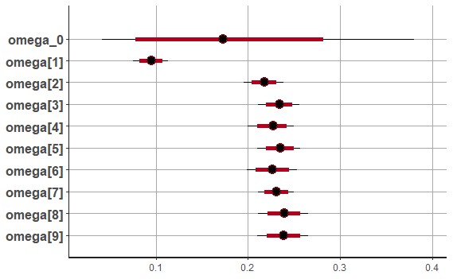

```r
plot(fit_ba, pars = c("omega_0", "omega"))
```

```
ci_level: 0.8 (80% intervals)
outer_level: 0.95 (95% intervals)
```

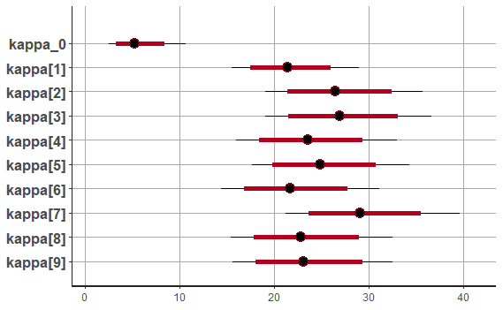

```r
plot(fit_ba, pars = c("kappa_0", "kappa"))
```

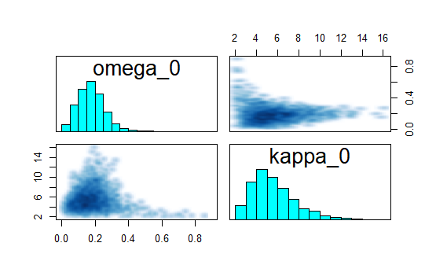

```r
pairs(fit_ba, pars = c("omega_0", "kappa_0"))
```

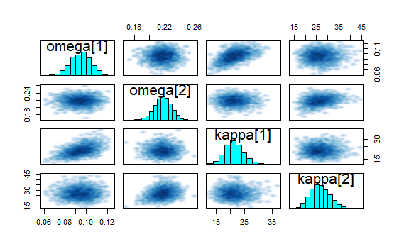

```r
pairs(fit_ba, pars = c("omega[1]", "omega[2]",
                       "kappa[1]", "kappa[2]"))
```

## Exploring the prior

```stan
data {
  int<lower = 0> C;
  int<lower = 0> S;
  int<lower = 0> N[S];
  int<lower = 0> y[S];
  int<lower = 0> cats[S];
}
transformed data {
  real<lower = 0> A_omega_0;
  real<lower = 0> B_omega_0;
  real<lower = 0> R_kappa_0;

  A_omega_0 = 2;
  B_omega_0 = 2;
  R_kappa_0 = 1;
}
parameters {
  vector<lower = 0, upper = 1>[S] theta;
  vector<lower = 0, upper = 1>[C] omega;
  vector<lower = 0>[C] kappa_minus_two;
  real<lower = 0> kappa_minus_two_0;
  real<lower = 0, upper = 1> omega_0;
}
transformed parameters {
  real<lower = 2> kappa_0;
  vector<lower = 2>[C] kappa;
  real<lower = 0> a_0;
  real<lower = 0> b_0;
  vector<lower = 0>[C] a;
  vector<lower = 0>[C] b;

  kappa_0 = kappa_minus_two_0 + 2;
  a_0 = omega_0 * (kappa_0 - 2) + 1;
  b_0 = (1 - omega_0) * (kappa_0 - 2) + 1;
  kappa = kappa_minus_two + 2;
  a = omega .* (kappa - 2) + 1;
  b = (1 - omega) .* (kappa - 2) + 1;
}
model {
  omega_0 ~ beta(A_omega_0, B_omega_0);
  kappa_minus_two_0 ~ exponential(R_kappa_0);
  omega ~ beta(a_0, b_0);
  kappa_minus_two ~ exponential(R_kappa_0);
  theta ~ beta(a[cats], b[cats]);
//  y ~ binomial(N, theta);
}
```

```r
set.seed(11111)
fit_ba_prior <- sampling(ba_prior, data = stan_data, refresh = 0)
```

```
There were 2 chains where the estimated Bayesian Fraction of Missing Information was low. See
http://mc-stan.org/misc/warnings.html#bfmi-lowExamine the pairs() plot to diagnose sampling problems
```

```
ci_level: 0.8 (80% intervals)
outer_level: 0.95 (95% intervals)
```

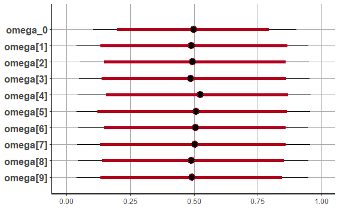

```r
plot(fit_ba_prior, pars = c("omega_0", "omega"))
```

```
ci_level: 0.8 (80% intervals)
outer_level: 0.95 (95% intervals)
```

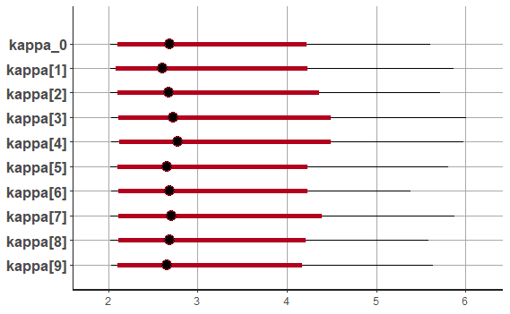

```r
plot(fit_ba_prior, pars = c("kappa_0", "kappa"))
```

```
ci_level: 0.8 (80% intervals)
outer_level: 0.95 (95% intervals)
```

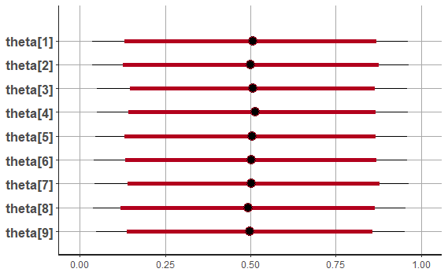

```r
plot(fit_ba_prior, pars = c("theta[1]", "theta[2]", "theta[3]",
                            "theta[4]", "theta[5]", "theta[6]",
                            "theta[7]", "theta[8]", "theta[9]"))
```

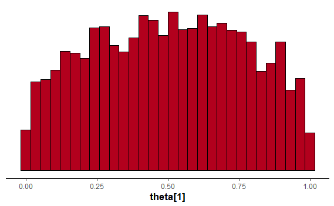

```r
plot(fit_ba_prior, plotfun = "hist", par = "theta[1]")
```

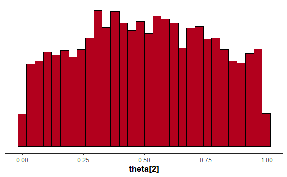

```r
plot(fit_ba_prior, plotfun = "hist", par = "theta[2]")
```

They’re all pretty much uniform from 0 to 1 as we’d expect without any data included.

## Posterior predictive check

Extract predicted values:

```r
samples_ba <- extract(fit_ba)
y_rep <- samples_ba$y_rep
```

Graph values of $y$ against summaries of $y_{rep}$.

Here’s the first player (a pitcher):

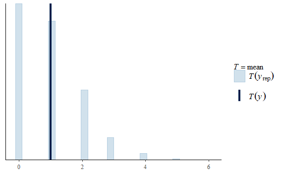

```r
ppc_stat(y[1], as.matrix(y_rep[ , 1]))
```

Here’s the 4th player (2nd baseman):

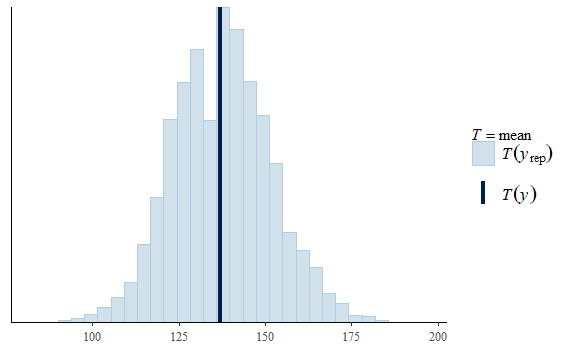

```r
ppc_stat(y[4], as.matrix(y_rep[ , 4]))
```

Here’s the 8th player (1st baseman):

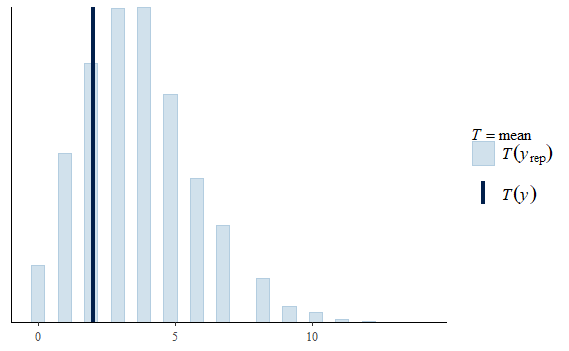

```r
ppc_stat(y[8], as.matrix(y_rep[ , 8]))
```

Here are the first nine players:

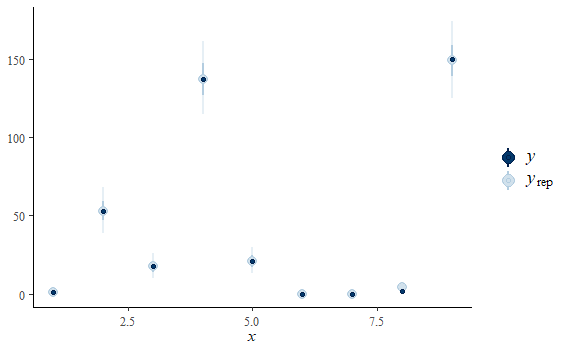

```r
ppc_intervals(y[1:9], y_rep[ , 1:9])
```

The posterior data distributions are basically lining up with the original data:

```r
ba_data[1:9, ]
```

| Player | PriPos | Hits | AtBats | PlayerNumber | PriPosNumber |
| --- | --- | --- | --- | --- | --- |
| Fernando Abad | Pitcher | 1 | 7 | 1 | 1 |
| Bobby Abreu | Left Field | 53 | 219 | 2 | 7 |
| Tony Abreu | 2nd Base | 18 | 70 | 3 | 4 |
| Dustin Ackley | 2nd Base | 137 | 607 | 4 | 4 |
| Matt Adams | 1st Base | 21 | 86 | 5 | 3 |
| Nathan Adcock | Pitcher | 0 | 1 | 6 | 1 |
| Jeremy Affeldt | Pitcher | 0 | 1 | 7 | 1 |
| Brandon Allen | 1st Base | 2 | 20 | 8 | 3 |
| Yonder Alonso | 1st Base | 150 | 549 | 9 | 3 |

For low values of `AtBats`, the variability is necessarily low because there are only so many values of `Hits` possible.

There is some shrinkage visible. It would be more prominent for people with low values of `AtBats`. (Less data means the prior is more powerful.) For those with high `AtBats`, the data speaks loudly, so the posterior data draws are centered pretty much right at the data value.

The following makes some comparisons between positions:

```r
pitchers <- samples_ba$omega[ , 1]
catchers <- samples_ba$omega[ , 2]
firstbase <- samples_ba$omega[ , 3]

positions_df <- bind_cols(pitchers = pitchers,
                          catchers = catchers,
                          firstbase = firstbase)
```

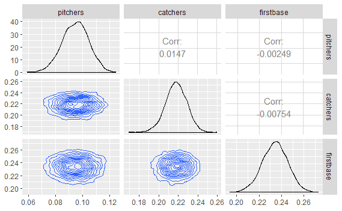

```r
ggpairs(positions_df, lower = list(continuous = "density"))
```

```r
positions_df <- positions_df %>%
  mutate(pitchers_catchers = pitchers - catchers,
         catchers_firstbase = catchers - firstbase)
```

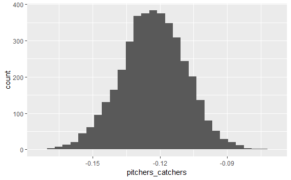

```r
ggplot(positions_df, aes(x = pitchers_catchers)) +
  geom_histogram()
```

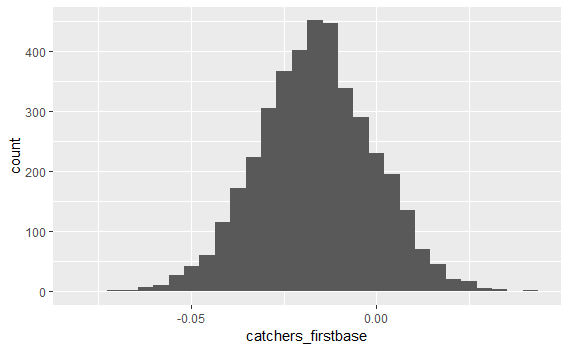

```r
ggplot(positions_df, aes(x = catchers_firstbase)) +
  geom_histogram()
```

Here are some comparisons between individual players:

```r
players <- c("Kyle Blanks", "Bruce Chen",
            "ShinSoo Choo", "Ichiro Suzuki")
player_nums <- ba_data %>%
  filter(Player %in% players) %>%
  .$PlayerNumber
player_nums
```

```
[1]  75 156 159 844
```

```r
players_df <- as_tibble(samples_ba$theta[ , player_nums])
```

```
`as_tibble.matrix()` requires a matrix with column names or a `.name_repair` argument. Using compatibility `.name_repair`.
```

```r
colnames(players_df) <- players
players_df
```

| Kyle Blanks | Bruce Chen | ShinSoo Choo | Ichiro Suzuki |
| --- | --- | --- | --- |
| 0.18781566 | 0.13712880 | 0.2872037 | 0.2714401 |
| 0.28865472 | 0.15294591 | 0.2338604 | 0.2802968 |
| 0.10520960 | 0.01268618 | 0.3024871 | 0.2680985 |
| 0.27718916 | 0.14533820 | 0.3074231 | 0.2778649 |
| 0.29151686 | 0.11489683 | 0.2897812 | 0.2851906 |
| 0.14049099 | 0.04848545 | 0.2917650 | 0.2646458 |
| 0.19719535 | 0.16843487 | 0.2975603 | 0.3060226 |
| 0.30880087 | 0.15345014 | 0.2622866 | 0.2926010 |
| 0.27502504 | 0.17928436 | 0.2908168 | 0.2622600 |
| 0.27535494 | 0.22768725 | 0.2881629 | 0.3288642 |

[output cut: 990 more lines]

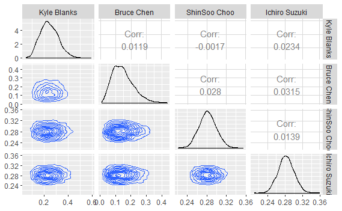

```r
ggpairs(players_df, lower = list(continuous = "density"))
```

```r
players_df <- players_df %>%
  mutate(Blanks_Chen = `Kyle Blanks` - `Bruce Chen`,
         Choo_Suzuki = `ShinSoo Choo` - `Ichiro Suzuki`)
```

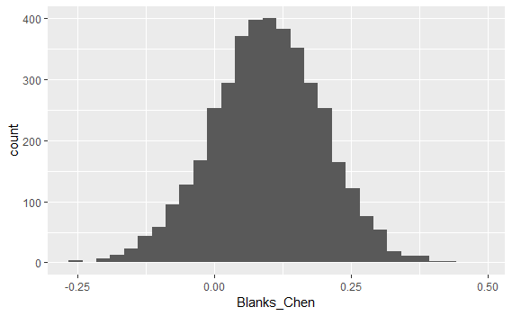

```r
ggplot(players_df, aes(Blanks_Chen)) +
  geom_histogram()
```

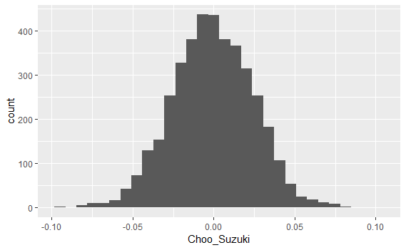

```r
ggplot(players_df, aes(Choo_Suzuki)) +
  geom_histogram()
```

## ShinyStan

Run the following code from the Console:

```
launch_shinystan(fit_ba)
```